# Assignment 2 CITS5508

#### D2 [2 marks]:

Provide a few comments about what you can observe from the scatter plot:

1. What can be observed regarding the relationship between these features?
2. Can you observe the presence of clusters of groups? How do they relate to the target variable?
3. Are there any instances that could be outliers?
4. Are there features that could be removed? Why or why not?

#### D3 [1 mark]:

Compute and show the correlation matrix where each cell contains the correlation coefficient between the corresponding pair of features (Hint: you may use the heatmap function from the seaborn package).

```python
# Calculate the correlation matrix for the DataFrame, The correlation matrix shows how closely related each pair of features are to each other

# Select the first 10 features from the DataFrame
first_10_features = X_df.iloc[:, :10]

# Calculate the correlation matrix for the first 10 features
correlation_matrix = first_10_features.corr()
```

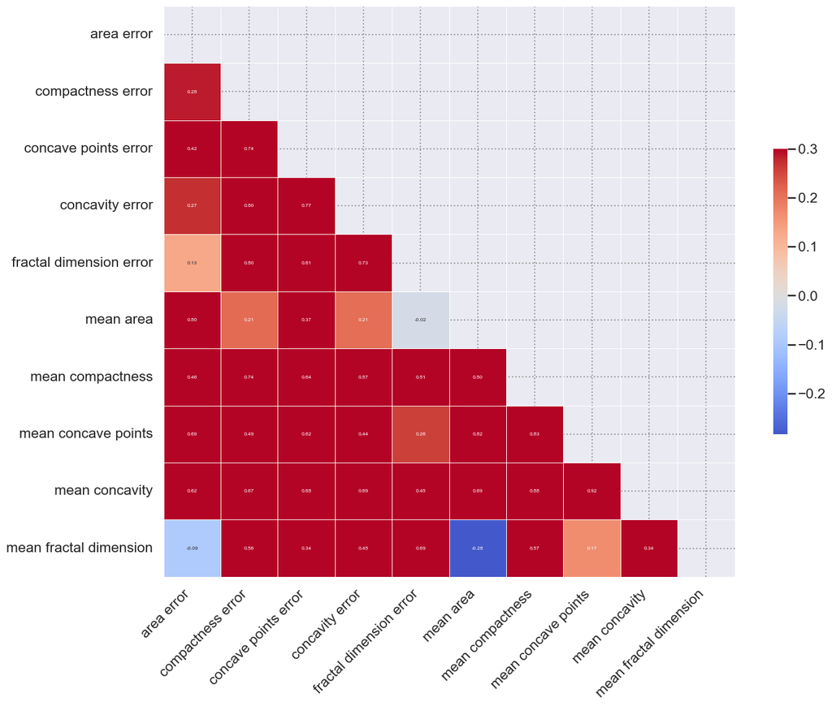

```python
# Set the size of the figure for the heatmap
plt.figure(figsize=(16, 12))

# Generate a mask for the upper triangle of the correlation matrix
# This mask will be used to hide the upper triangle, as the matrix is symmetrical
mask = np.triu(np.ones_like(correlation_matrix, dtype=bool))

# Create the heatmap using seaborn
# 'mask' hides the upper triangle of the matrix, 'cmap' sets the color palette
# 'vmax' controls the maximum correlation value for color scaling, 'center' sets the center of the colormap at zero
# 'square' ensures each cell is square-shaped, 'linewidths' sets the width of the lines that will divide each cell
# 'cbar_kws' adjusts the size of the color bar, 'annot' enables annotations inside the squares
# 'fmt' specifies the string formatting for annotations, 'annot_kws' adjusts the size of the annotations
sns.heatmap(correlation_matrix, mask=mask, cmap='coolwarm', vmax=.3, center=0,
            square=True, linewidths=.5, cbar_kws={"shrink": .5}, annot=True, fmt=".2f", annot_kws={"size": 6})

# Rotate the labels on the x-axis to 45 degrees for better readability
# 'ha' sets the horizontal alignment of the labels
plt.xticks(rotation=45, ha='right')

# Display the heatmap
plt.show()
```

#### D4 [1 mark]:

Do the correlation coefficients support your previous observations?

#### D4 Answer:

The heatmap's high correlation values confirm the suspected redundancy among some features. It's also beneficial for quickly pinpointing which features are least correlated with others, suggesting potential candidates for removal to simplify the model without sacrificing predictive power.

#### D5:

In a data science project, it’s crucial not just to remove highly correlated features but to consider the context and implications of feature selection carefully. Blindly dropping features may lead to the loss of valuable information or unintended bias in the model’s performance. Here, for the assignment context, we will drop a few features to simplify the classification tasks and speed up the computational time. Create a code that drop the features: mean perimeter, mean radius, worst radius, worst perimeter and radius error. These are features with a linear correlation higher than 0.97 in magnitude with some other features kept in the data. After this process, your data matrix should be updated accordingly and contain 25 features. Task D5 must be performed; otherwise, your order deliverable tasks will be incorrect. However, there are no marks for task D5.

```python
# Drop specified columns from the DataFrame
# 'labels' specifies the column names to remove, 'axis=1' indicates that columns (not rows) are being dropped
X_df = X_df.drop(labels=['mean perimeter', 'mean radius', 'worst radius', 'worst perimeter', 'radius error'], axis=1)

# Print the new shape of the DataFrame to confirm the number of remaining columns and rows
print(X_df.shape)
```

```
(569, 25)
```

### Fitting a Decision Tree model with default hyperparameters

#### D6 [3 marks]:

Fit a decision tree classifier using default hyperparameters using 80% of the data. Remember to set the random generator’s state to the value “5508” (for both the split and class). Use the trained classifier to perform predictions on the training and test sets. Provide the accuracy, precision and recall scores for both sets and the confusion matrix for the test set.

```python
# Split the dataset into training and validation sets
# 'test_size=0.2' specifies that 20% of the data is used for the validation set
# 'random_state=5508' ensures reproducibility of the results by setting a seed for the random number generator
X_train, X_val, y_train, y_val = train_test_split(X_df, y, test_size=0.2, random_state=5508)

# Initialize the Decision Tree Classifier
clf = DecisionTreeClassifier(random_state=5508)

# Fit the Decision Tree Classifier on the training data
clf.fit(X_train, y_train)
```

```
DecisionTreeClassifier(random_state=5508)
```

```python
# Make predictions on the training set using the trained classifier
y_train_pred = clf.predict(X_train)

# Make predictions on the validation set using the trained classifier
y_val_pred = clf.predict(X_val)

# Reporting the results for the training set
# Calculate and store accuracy, precision, and recall
# 'average='macro'' calculates metrics globally by averaging the scores for each class
train_results = {
    'Accuracy': round(accuracy_score(y_train, y_train_pred),2),
    'Precision': round(precision_score(y_train, y_train_pred, average='macro'),2),
    'Recall': round(recall_score(y_train, y_train_pred, average='macro'),2)
}

# Reporting the results for the validation set
val_results = {
    'Accuracy': round(accuracy_score(y_val, y_val_pred),2),
    'Precision': round(precision_score(y_val, y_val_pred, average='macro'),2),
    'Recall': round(recall_score(y_val, y_val_pred, average='macro'),2),
}

# Generate the confusion matrix for the validation set
val_confusion_matrix = confusion_matrix(y_val, y_val_pred)
```

```python
# Convert the training results dictionary to a DataFrame for better readability and display
train_results_df = pd.DataFrame([train_results])

# Print a statement to clearly indicate that the following output is the training results
print("Training Results:")

# Display the DataFrame containing the training results
display(train_results_df)
```

```
Training Results:
```

|  | Accuracy | Precision | Recall |
| --- | --- | --- | --- |
| 0 | 1.0 | 1.0 | 1.0 |

```python
# Convert the validation results dictionary to a DataFrame for better readability and display
val_results_df = pd.DataFrame([val_results])

# Print a statement to clearly indicate that the following output is the testing results
print("Testing Results:")

# Display the DataFrame containing the validation results
display(val_results_df)
```

```
Testing Results:
```

|  | Accuracy | Precision | Recall |
| --- | --- | --- | --- |
| 0 | 0.96 | 0.96 | 0.96 |

```python
def plot_heatmap(data, ax, title):
    """
    Function to visualize data as a heatmap, typically used for confusion matrices.

    Parameters:
        data (array-like): The confusion matrix or any matrix-like data structure.
        ax (matplotlib.axes.Axes): The axes on which to draw the heatmap.
        title (str): The title for the heatmap.

    This function draws a heatmap with annotations for each cell, customized color mapping,
    and labels for axes and title. The annotations inside the heatmap display the data values,
    making it easier to interpret the matrix.
    """

    # Plot the heatmap using seaborn
    sns.heatmap(data, annot=True, fmt="d", cmap="coolwarm", ax=ax,
                annot_kws={"size": 12}, square=True)  # Display data as integers in each cell

    # Set the labels for the axes and the title of the heatmap
    ax.set_xlabel('Predicted Labels', fontsize=12)  # Label for the x-axis
    ax.set_ylabel('True Labels', fontsize=12)      # Label for the y-axis
    ax.set_title(title, fontsize=14)               # Title for the heatmap
```

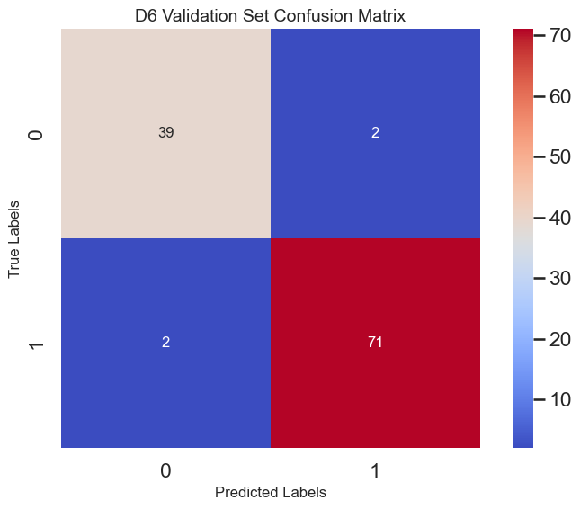

```python
# Create a figure and an axes object for plotting
# The subplot is configured to have 1 row and 1 column
# figsize specifies the size of the figure in inches (width, height)
fig, ax = plt.subplots(1, 1, figsize=(8, 6))

# Use the custom plot_heatmap function to draw the heatmap of the validation confusion matrix
# 'val_confusion_matrix' is the data to be visualized, and 'ax' is the axes object for the plot
plot_heatmap(val_confusion_matrix, ax, 'D6 Validation Set Confusion Matrix')

# Adjust the layout of the plot to make sure there is no content clipping
plt.tight_layout()

# Display the plot on screen
plt.show()
```

#### D7 [2 marks]:

Comment on these results. Do you think your classifier is overfitting? If so, why this is happening? If not, why not?

#### D7 Answer:

Possibly, yes. Perfect training scores indicate that the model may have learned the training data too well, including noise and outliers, which do not generalize to new data. The drop in testing metrics supports this, though it's a small drop, not an extreme one. Overfitting in a decision tree classifier can occur for several reasons:

- Minimum split size: If the tree is allowed to split until the nodes contain very few samples, it can lead to rules that are too specific to the training data. Nodes that represent only a few samples are likely representing noise or outliers.
- Irrelevant features: including features that do not have predictive power can lead the model to create splits based on noise, which again leads to overfitting.

#### D8 [2 marks]:

Display the decision tree built from the training process (like the one shown in Figure 6.1 of the textbook for the iris dataset).

```python
# Export the trained Decision Tree classifier to a Graphviz file format (.dot)
# 'clf' is the trained Decision Tree classifier
# 'out_file' specifies the file to save the dot output
# 'feature_names' provides the names of the features used in the tree
# 'class_names' specifies the names of the classes in the target variable
# 'rounded' and 'filled' enhance the visual aesthetics of the tree diagram
# 'special_characters' allows special characters to be handled in feature and class names

export_graphviz(
    clf,
    out_file="breast_tree.dot",
    feature_names=X_df.columns,
    class_names=breast_df.target_names,
    rounded=True,
    filled=True,
    special_characters=True
)

# Open the exported .dot file and read its contents into a string
with open("breast_tree.dot") as f:
    dot_graph = f.read()

# Create a Graphviz object from the dot graph
graph = graphviz.Source(dot_graph)
graph  # Display the graph if in an interactive environment like Jupyter Notebook
```

[figure not shown]

#### D9 [2 marks]:

Study the tree diagram and comment on the following:

1. How many levels resulted from the model?
2. Did the diagram help you to confirm whether the classifier has an overfitting issue?
3. What can you observe from the leaves?
4. Is this an interpretable model?

#### D10 [3 marks]:

Repeat the data split another four times, each using 80% of the data to train the model and the remaining 20% for testing. For these splits, set the seed of the random state to the values “5509”, “5510”, “5511” and “5512”. The random state of the model can be kept at “5508”.

For each of these four splits, fit the decision tree classifier and use the trained classifier to perform predictions on the test set. Provide three plots to show the accuracy, precision and recall scores for the test set for each split and comment on the consistency of the results in the five splits (including the original split with random state “5508”).

```python
# Set the seed of the random state to the value "5509" and split the dataset
# This ensures reproducibility for the training and validation sets with this specific seed
X_train_seed_5509, X_val_seed_5509, y_train_seed_5509, y_val_seed_5509 = train_test_split(X_df, y, test_size=0.2, random_state=5509)

# Initialize and train a Decision Tree classifier with the first seed
clf_seed_5509 = DecisionTreeClassifier(random_state=5508)
clf_seed_5509.fit(X_train_seed_5509, y_train_seed_5509)

# Repeat the process with a new seed "5510" for different random splits
X_train_seed_5510, X_val_seed_5510, y_train_seed_5510, y_val_seed_5510 = train_test_split(X_df, y, test_size=0.2, random_state=5510)
clf_seed_5510 = DecisionTreeClassifier(random_state=5508)
clf_seed_5510.fit(X_train_seed_5510, y_train_seed_5510)

# Repeat the process with another seed "5511"
X_train_seed_5511, X_val_seed_5511, y_train_seed_5511, y_val_seed_5511 = train_test_split(X_df, y, test_size=0.2, random_state=5511)
clf_seed_5511 = DecisionTreeClassifier(random_state=5508)
clf_seed_5511.fit(X_train_seed_5511, y_train_seed_5511)

# Finally, use the seed "5512" for the last set of splits and training
X_train_seed_5512, X_val_seed_5512, y_train_seed_5512, y_val_seed_5512 = train_test_split(X_df, y, test_size=0.2, random_state=5512)
clf_seed_5512 = DecisionTreeClassifier(random_state=5508)
clf_seed_5512.fit(X_train_seed_5512, y_train_seed_5512)
```

```
DecisionTreeClassifier(random_state=5508)
```

```python
# Make predictions on the validation sets for each seed
y_val_pred_seed_5509 = clf_seed_5509.predict(X_val_seed_5509)
y_val_pred_seed_5510 = clf_seed_5510.predict(X_val_seed_5510)
y_val_pred_seed_5511 = clf_seed_5511.predict(X_val_seed_5511)
y_val_pred_seed_5512 = clf_seed_5512.predict(X_val_seed_5512)

# Collect all validation results for each seed into a dictionary
# Each entry in the dictionary corresponds to one of the trained models using different random states
# The results include accuracy, precision, and recall for each model's predictions
all_val_seed_results = {
    'val_results_seed_5508': {  # Previously stored results for reference
        'Accuracy': round(accuracy_score(y_val, y_val_pred),2),
        'Precision': round(precision_score(y_val, y_val_pred, average='macro'),2),
        'Recall': round(recall_score(y_val, y_val_pred, average='macro'),2),
    },
    'val_results_seed_5509': {
        'Accuracy': round(accuracy_score(y_val_seed_5509, y_val_pred_seed_5509),2),
        'Precision': round(precision_score(y_val_seed_5509, y_val_pred_seed_5509, average='macro'),2),
        'Recall': round(recall_score(y_val_seed_5509, y_val_pred_seed_5509, average='macro'),2),
    },
    'val_results_seed_5510': {
        'Accuracy': round(accuracy_score(y_val_seed_5510, y_val_pred_seed_5510),2),
        'Precision': round(precision_score(y_val_seed_5510, y_val_pred_seed_5510, average='macro'),2),
        'Recall': round(recall_score(y_val_seed_5510, y_val_pred_seed_5510, average='macro'),2),
    },
    'val_results_seed_5511': {
        'Accuracy': round(accuracy_score(y_val_seed_5511, y_val_pred_seed_5511),2),
        'Precision': round(precision_score(y_val_seed_5511, y_val_pred_seed_5511, average='macro'),2),
        'Recall': round(recall_score(y_val_seed_5511, y_val_pred_seed_5511, average='macro'),2),
    },
    'val_results_seed_5512': {
        'Accuracy': round(accuracy_score(y_val_seed_5512, y_val_pred_seed_5512),2),
        'Precision': round(precision_score(y_val_seed_5512, y_val_pred_seed_5512, average='macro'),2),
        'Recall': round(recall_score(y_val_seed_5512, y_val_pred_seed_5512, average='macro'),2),
    }
}
```

```python
# Convert the dictionary containing validation results for different seeds into a DataFrame
# 'orient='index'' specifies that dictionary keys should be used as row labels
all_val_seed_results_df = pd.DataFrame.from_dict(all_val_seed_results, orient='index')

# Display the DataFrame containing the results
display(all_val_seed_results_df)
```

|  | Accuracy | Precision | Recall |
| --- | --- | --- | --- |
| val_results_seed_5508 | 0.96 | 0.96 | 0.96 |
| val_results_seed_5509 | 0.96 | 0.98 | 0.94 |
| val_results_seed_5510 | 0.92 | 0.91 | 0.92 |
| val_results_seed_5511 | 0.93 | 0.92 | 0.93 |
| val_results_seed_5512 | 0.94 | 0.93 | 0.94 |

```python
# Extracting the seeds used in the models as a list of keys from the results dictionary
seeds = list(all_val_seed_results.keys())

# Using list comprehensions to extract accuracy scores for each seed from the results dictionary
accuracies = [all_val_seed_results[seed]['Accuracy'] for seed in seeds]

# Using list comprehensions to extract precision scores for each seed from the results dictionary
precisions = [all_val_seed_results[seed]['Precision'] for seed in seeds]

# Using list comprehensions to extract recall scores for each seed from the results dictionary
recalls = [all_val_seed_results[seed]['Recall'] for seed in seeds]

# Printing the extracted scores for accuracy, precision, and recall
print("Accuracy: ", accuracies)
print("Precision: ", precisions)
print("Recall: ", recalls)
```

```
Accuracy:  [0.96, 0.96, 0.92, 0.93, 0.94]
Precision:  [0.96, 0.98, 0.91, 0.92, 0.93]
Recall:  [0.96, 0.94, 0.92, 0.93, 0.94]
```

```python
# Define a function to add value labels on top of each bar in the bar plots
def add_value_labels(ax, data, fontsize=10):
    # Iterate over each rectangle (bar) and corresponding value in the bar plot
    for rect, value in zip(ax.patches, data):
        # Annotate the bars with their respective values formatted to two decimal places
        ax.annotate(
            format(value, '.2f'),
            (rect.get_x() + rect.get_width() / 2, rect.get_height()),  # Position at the center-top of the bar
            ha='center', va='center',  # Center align the text horizontally and vertically
            xytext=(0, 5), textcoords='offset points', fontsize=fontsize  # Slightly offset the text upwards
        )
```

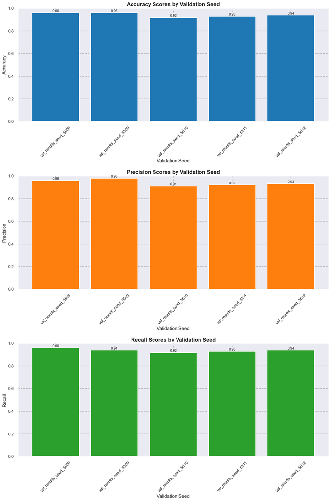

```python
# Set the style and context for the plots using seaborn
sns.set_context("talk")  # Enhances the scale of labels and lines for better readability
sns.set_style("darkgrid", {"grid.color": ".6", "grid.linestyle": ":"})  # Dark grid with specified color and linestyle

# Extracting the scores for plotting
seeds = list(all_val_seed_results.keys())
accuracies = [all_val_seed_results[seed]['Accuracy'] for seed in seeds]
precisions = [all_val_seed_results[seed]['Precision'] for seed in seeds]
recalls = [all_val_seed_results[seed]['Recall'] for seed in seeds]

# Custom colors for the bars and the width of the bars
colors = ['#1f77b4', '#ff7f0e', '#2ca02c']
bar_width = 0.8

# Create a figure with multiple axes to plot each metric
fig, axes = plt.subplots(nrows=3, ncols=1, figsize=(14, 21), dpi=100)

# Titles and labels for each subplot
titles = ['Accuracy Scores by Validation Seed', 'Precision Scores by Validation Seed', 'Recall Scores by Validation Seed']
y_labels = ['Accuracy', 'Precision', 'Recall']

# Loop through each metric and create a bar plot
for i, (ax, metric, title, color) in enumerate(zip(axes, [accuracies, precisions, recalls], titles, colors)):
    bars = ax.bar(seeds, metric, color=color, width=bar_width)  # Create a bar plot
    ax.set_title(title, fontsize=16, fontweight='bold')  # Set title with custom fontsize and bold fontweight
    ax.set_xlabel('Validation Seed', fontsize=14)  # Set the x-axis label
    ax.set_ylabel(y_labels[i], fontsize=14)  # Set the y-axis label
    ax.set_ylim([0, 1])  # Set the limits for the y-axis to range from 0 to 1
    ax.grid(axis='y', linestyle='--', alpha=0.7)  # Add a grid on the y-axis for better readability of scale
    ax.tick_params(axis='x', rotation=45)  # Rotate x-axis labels for better visibility
    ax.tick_params(axis='both', which='major', labelsize=12)  # Adjust the size of major ticks
    add_value_labels(ax, metric)  # Call function to add value labels to the bars

# Adjust the overall layout to ensure no clipping of content
plt.tight_layout()
# Display the plot
plt.show()
```

#### D10 Answer:

Consistency Across Metrics:

Accuracy: The accuracy scores show very high consistency, with values ranging narrowly from 0.92 to 0.96 across different seeds. This demonstrates that the model consistently classifies both classes (malignant and benign) accurately across various splits. The highest accuracy occurs at seeds 5508 and 5509 with 0.96, indicating optimal model performance with these data configurations.

Precision: Precision scores are also consistent, though they exhibit a slightly wider range from 0.91 at seed 5510 to 0.98 at seed 5509. This indicates that the model's ability to avoid false positives is mostly stable, though some variability can be observed, suggesting slight fluctuations in performance under different data distributions. The peak precision at seed 5509 (0.98) shows the model's best performance in identifying true positives accurately.

#### D11 [3 marks]:

Investigate the impact of the training size on the performance of the model. You will do five different splits: 50%-50% (training the model on 50% of the data and testing on the remaining 50%), 60%-40%, 70%-30%, 80%-20% and 90%-10%. For each of these data splits, set back the seed of the random state to the value “5508”. Provide three plots to show the accuracy, precision and recall scores for the test set for each data split and comment on the results. Did the performance behave as you expected?

```python
# Split the dataset with a 50-50 train-validation ratio and a fixed random state for reproducibility
X_train_split_5050, X_val_split_5050, y_train_split_5050, y_val_split_5050 = train_test_split(X_df, y, test_size=0.5, random_state=5508)
clf_split_5050 = DecisionTreeClassifier(random_state=5508)
clf_split_5050.fit(X_train_split_5050, y_train_split_5050)  # Train the classifier on the 50-50 split data

# Split the dataset with a 60-40 train-validation ratio
X_train_split_6040, X_val_split_6040, y_train_split_6040, y_val_split_6040 = train_test_split(X_df, y, test_size=0.6, random_state=5508)
clf_split_6040 = DecisionTreeClassifier(random_state=5508)
clf_split_6040.fit(X_train_split_6040, y_train_split_6040)  # Train the classifier on the 60-40 split data

# Split the dataset with a 70-30 train-validation ratio
X_train_split_7030, X_val_split_7030, y_train_split_7030, y_val_split_7030 = train_test_split(X_df, y, test_size=0.7, random_state=5508)
clf_split_7030 = DecisionTreeClassifier(random_state=5508)
clf_split_7030.fit(X_train_split_7030, y_train_split_7030)  # Train the classifier on the 70-30 split data

# Split the dataset with an 80-20 train-validation ratio
X_train_split_8020, X_val_split_8020, y_train_split_8020, y_val_split_8020 = train_test_split(X_df, y, test_size=0.8, random_state=5508)
clf_split_8020 = DecisionTreeClassifier(random_state=5508)
clf_split_8020.fit(X_train_split_8020, y_train_split_8020)  # Train the classifier on the 80-20 split data

# Split the dataset with a 90-10 train-validation ratio
X_train_split_9010, X_val_split_9010, y_train_split_9010, y_val_split_9010 = train_test_split(X_df, y, test_size=0.9, random_state=5508)
clf_split_9010 = DecisionTreeClassifier(random_state=5508)
clf_split_9010.fit(X_train_split_9010, y_train_split_9010)  # Train the classifier on the 90-10 split data
```

```
DecisionTreeClassifier(random_state=5508)
```

```python
# Make predictions on the validation sets for each different train-validation split
y_val_pred_split_5050 = clf_split_5050.predict(X_val_split_5050)
y_val_pred_split_6040 = clf_split_6040.predict(X_val_split_6040)
y_val_pred_split_7030 = clf_split_7030.predict(X_val_split_7030)
y_val_pred_split_8020 = clf_split_8020.predict(X_val_split_8020)
y_val_pred_split_9010 = clf_split_9010.predict(X_val_split_9010)

# Consolidate the accuracy, precision, and recall for each validation split into a dictionary
# This allows for easy comparison of model performance across different splits
all_val_split_results = {
    'val_results_split_5050': {
        'Accuracy': round(accuracy_score(y_val_split_5050, y_val_pred_split_5050),2),
        'Precision': round(precision_score(y_val_split_5050, y_val_pred_split_5050, average='macro'),2),
        'Recall': round(recall_score(y_val_split_5050, y_val_pred_split_5050, average='macro'),2),
    },
    'val_results_split_6040': {
        'Accuracy': round(accuracy_score(y_val_split_6040, y_val_pred_split_6040),2),
        'Precision': round(precision_score(y_val_split_6040, y_val_pred_split_6040, average='macro'),2),
        'Recall': round(recall_score(y_val_split_6040, y_val_pred_split_6040, average='macro'),2),
    },
    'val_results_split_7030': {
        'Accuracy': round(accuracy_score(y_val_split_7030, y_val_pred_split_7030),2),
        'Precision': round(precision_score(y_val_split_7030, y_val_pred_split_7030, average='macro'),2),
        'Recall': round(recall_score(y_val_split_7030, y_val_pred_split_7030, average='macro'),2),
    },
    'val_results_split_8020': {
        'Accuracy': round(accuracy_score(y_val_split_8020, y_val_pred_split_8020),2),
        'Precision': round(precision_score(y_val_split_8020, y_val_pred_split_8020, average='macro'),2),
        'Recall': round(recall_score(y_val_split_8020, y_val_pred_split_8020, average='macro'),2),
    },
    'val_results_split_9010': {
        'Accuracy': round(accuracy_score(y_val_split_9010, y_val_pred_split_9010),2),
        'Precision': round(precision_score(y_val_split_9010, y_val_pred_split_9010, average='macro'),2),
        'Recall': round(recall_score(y_val_split_9010, y_val_pred_split_9010, average='macro'),2),
    }
}
```

```python
# Convert the dictionary containing the evaluation metrics for different validation splits into a DataFrame
# 'orient='index'' specifies that dictionary keys (validation split identifiers) should be used as row labels
all_val_split_results_df = pd.DataFrame.from_dict(all_val_split_results, orient='index')

# Display the DataFrame containing the evaluation results
display(all_val_split_results_df)
```

|  | Accuracy | Precision | Recall |
| --- | --- | --- | --- |
| val_results_split_5050 | 0.87 | 0.86 | 0.86 |
| val_results_split_6040 | 0.92 | 0.91 | 0.92 |
| val_results_split_7030 | 0.94 | 0.94 | 0.94 |
| val_results_split_8020 | 0.93 | 0.94 | 0.92 |
| val_results_split_9010 | 0.93 | 0.94 | 0.91 |

```python
# Define a function to add value labels on top of each bar in the bar plots
def add_value_labels(ax, data, fontsize=10):
    for rect, value in zip(ax.patches, data):
        # Annotate the bars with their respective values formatted to two decimal places
        ax.annotate(
            format(value, '.2f'),
            (rect.get_x() + rect.get_width() / 2, rect.get_height()),  # Position at the center-top of the bar
            ha='center', va='center',  # Center align the text horizontally and vertically
            xytext=(0, 5), textcoords='offset points', fontsize=fontsize  # Slightly offset the text upwards
        )
```

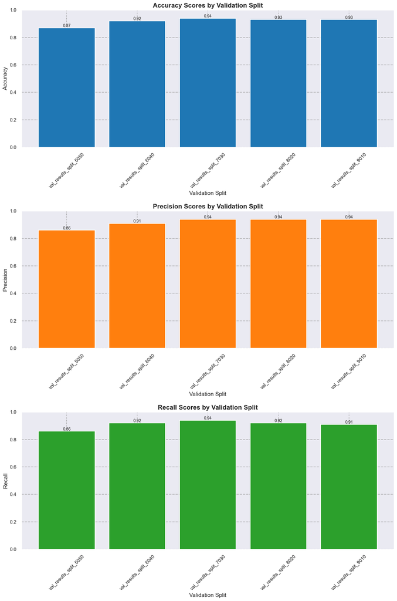

```python
# Set the style and context for the plots using seaborn
sns.set_context("talk")  # Enhances the scale of labels and lines for better readability
sns.set_style("darkgrid", {"grid.color": ".6", "grid.linestyle": ":"})  # Dark grid with specified color and linestyle

# Extract the scores for plotting
splits = list(all_val_split_results.keys())  # List of split names
accuracies = [all_val_split_results[split]['Accuracy'] for split in splits]
precisions = [all_val_split_results[split]['Precision'] for split in splits]
recalls = [all_val_split_results[split]['Recall'] for split in splits]

# Custom colors for the bars and the width of the bars
colors = ['#1f77b4', '#ff7f0e', '#2ca02c']
bar_width = 0.8

# Create a figure with multiple axes to plot each metric
fig, axes = plt.subplots(nrows=3, ncols=1, figsize=(14, 21), dpi=100)

# Titles and labels for each subplot
titles = ['Accuracy Scores by Validation Split', 'Precision Scores by Validation Split', 'Recall Scores by Validation Split']
y_labels = ['Accuracy', 'Precision', 'Recall']

# Loop through each metric and create a bar plot
for i, (ax, metric, title, color) in enumerate(zip(axes, [accuracies, precisions, recalls], titles, colors)):
    bars = ax.bar(splits, metric, color=color, width=bar_width)  # Create a bar plot
    ax.set_title(title, fontsize=16, fontweight='bold')  # Set title with custom fontsize and bold fontweight
    ax.set_xlabel('Validation Split', fontsize=14)  # Set the x-axis label
    ax.set_ylabel(y_labels[i], fontsize=14)  # Set the y-axis label
    ax.set_ylim([0, 1])  # Set the limits for the y-axis to range from 0 to 1
    ax.grid(axis='y', linestyle='--', alpha=0.7)  # Add a grid on the y-axis for better readability of scale
    ax.tick_params(axis='x', rotation=45)  # Rotate x-axis labels for better visibility
    ax.tick_params(axis='both', which='major', labelsize=12)  # Adjust the size of major ticks
    add_value_labels(ax, metric)  # Call function to add value labels to the bars

# Adjust the overall layout to ensure no clipping of content
plt.tight_layout()
# Display the plot
plt.show()
```

### Fitting a Decision Tree model with optimal hyperparameters

#### D12 [4 marks]:

Create a training set using 80% of the data and a test set with the remaining 20%. Use a 10-fold cross-validation and grid-search to find the optimal combination of hyperparameters max_depth — using values [2, 3, 4, 5], min_samples_split — using values [2, 4, 5, 10],and min_samples_leaf -— using values [2, 5] of a decision tree model. Remember to set the seed of the random state of the data split function and model class to the value “5508”. For the cross-validation, set the value of the random state to “42”. Use accuracy for the scoring argument of the grid-search function.

With the optimal obtained hyperparameters, retrain the model and report:

- The optimal hyperparameters;
- The obtained accuracy, precision and recall on the training set;
- The obtained accuracy, precision and recall on the test set;
- The confusion matrix on the test set.

```python
# Split the dataset into training and validation sets
# 'test_size=0.2' configures 20% of the data for validation, 'random_state=5508' ensures reproducibility
X_train_D12, X_val_D12, y_train_D12, y_val_D12 = train_test_split(X_df, y, test_size=0.2, random_state=5508)

# Configure StratifiedKFold for cross-validation
# 'n_splits=10' sets up 10 folds, 'random_state=42' ensures reproducibility, 'shuffle=True' randomizes the splits
skf = StratifiedKFold(n_splits=10, random_state=42, shuffle=True)

# Define the parameter grid to search for the best parameters of the Decision Tree
param_grid = {
    'max_depth': [2, 3, 4, 5],  # Potential depths of the tree to test
    'min_samples_split': [2, 4, 5, 10],  # Minimum number of samples required to split a node
    'min_samples_leaf': [2, 5]  # Minimum number of samples required at each leaf node
}

# Initialize the Decision Tree Classifier with a fixed random state
clf_D12 = DecisionTreeClassifier(random_state=5508)

# Set up GridSearchCV with the classifier, parameter grid, and cross-validator
# 'scoring='accuracy' configures the metric for performance evaluation
grid_search = GridSearchCV(clf_D12, param_grid, cv=skf, scoring='accuracy', n_jobs=-1, verbose=1)

# Fit the grid search to the training data
grid_search.fit(X_train_D12, y_train_D12)

# Extract the best parameters and the highest accuracy achieved
best_params = grid_search.best_params_
best_score = grid_search.best_score_

# Print the best parameters and accuracy found during the grid search
print("Best Parameters:", best_params)
print("Best Accuracy Score:", round(best_score,2))
```

```
Fitting 10 folds for each of 32 candidates, totalling 320 fits
```

```
Best Parameters: {'max_depth': 3, 'min_samples_leaf': 2, 'min_samples_split': 2}
Best Accuracy Score: 0.94
```

```python
# Initialize a Decision Tree Classifier with the best parameters found from the grid search
# 'random_state=5508' ensures the reproducibility of model training
# '**best_params' unpacks the dictionary of best parameters into the classifier's arguments
best_clf = DecisionTreeClassifier(random_state=5508, **best_params)

# Fit the classifier to the full training dataset
best_clf.fit(X_train, y_train)
```

```
DecisionTreeClassifier(max_depth=3, min_samples_leaf=2, random_state=5508)
```

```python
# Predict labels for the training set using the model with the best parameters
y_train_pred_best_parameter = best_clf.predict(X_train_D12)

# Predict labels for the validation set using the model with the best parameters
y_val_pred_best_parameter = best_clf.predict(X_val_D12)

# Compute evaluation metrics for the training and validation sets using the model with the best parameters
D12_train_val_results = {
    'train_results_D12': {
        'Accuracy': round(accuracy_score(y_train_D12, y_train_pred_best_parameter),2),
        'Precision': round(precision_score(y_train_D12, y_train_pred_best_parameter, average='macro'),2),
        'Recall': round(recall_score(y_train_D12, y_train_pred_best_parameter, average='macro'),2),
    },
    'val_results_D12': {
        'Accuracy': round(accuracy_score(y_val_D12, y_val_pred_best_parameter),2),
        'Precision': round(precision_score(y_val_D12, y_val_pred_best_parameter, average='macro'),2),
        'Recall': round(recall_score(y_val_D12, y_val_pred_best_parameter, average='macro'),2),
    }
}
```

```python
# Convert the dictionary containing the evaluation metrics for the training and validation sets
# into a DataFrame, where the keys become row labels
D12_train_val_results_df = pd.DataFrame.from_dict(D12_train_val_results, orient='index')

# Display the DataFrame containing the evaluation results for the training and validation sets
display(D12_train_val_results_df)
```

|  | Accuracy | Precision | Recall |
| --- | --- | --- | --- |
| train_results_D12 | 0.96 | 0.97 | 0.96 |
| val_results_D12 | 0.94 | 0.93 | 0.94 |

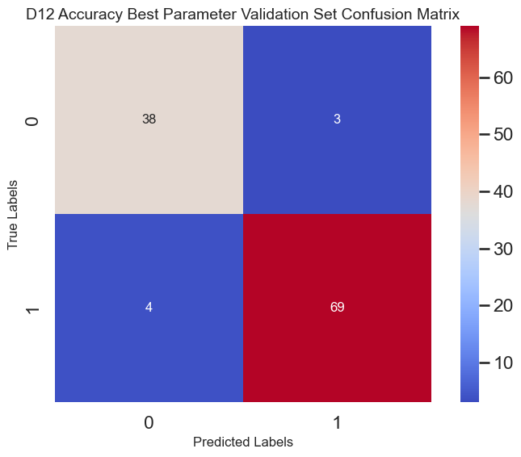

```python
# Compute the confusion matrix for the validation set using predictions from the model with the best parameters
D12_confusion_matrix = confusion_matrix(y_val_D12, y_val_pred_best_parameter)

# Create a figure and axis object
fig, ax = plt.subplots(1, 1, figsize=(8, 6))

# Plot the heatmap of the confusion matrix
plot_heatmap(D12_confusion_matrix, ax, 'D12 Accuracy Best Parameter Validation Set Confusion Matrix')

# Adjust layout to fit properly
plt.tight_layout()

# Display the plot
plt.show()
```

#### D13 [2 marks]:

Comment: What was the impact of fine-tuning the hyperparameters as opposed to what you obtained in D6? Has fine-tuning done what you expected?

#### D14 [3 marks]:

Repeat the training of task D12 twice: one considering the scoring argument of the grid-search function as precision and the other recall. For each of the scoring options (accuracy, precision, recall), provide the optimal hyperparame- ters according to the 10-fold cross-validation and grid-search, and, after retraining each model accordingly, provide the confusion matrix on the test set. Comment on the results, considering the problem.

```python
# PRECISION

# Create a Decision Tree Classifier
# 'random_state=5508' ensures reproducibility
clf_D14_precision = DecisionTreeClassifier(random_state=5508)

# Set up GridSearchCV for optimizing precision with 10-fold cross-validation
# 'scoring='precision' configures the metric for performance evaluation
grid_search = GridSearchCV(clf_D14_precision, param_grid, cv=skf, scoring='precision', n_jobs=-1, verbose=1)

# Fit the grid search to the training data
grid_search.fit(X_train_D12, y_train_D12)

# Extract the best parameters and the highest precision achieved
best_params_precision = grid_search.best_params_
best_score_precision = grid_search.best_score_

# Print the best parameters and precision found during the grid search
print("Best Parameters:", best_params_precision)
print("Best Precision Score:", round(best_score_precision,2))
```

```
Fitting 10 folds for each of 32 candidates, totalling 320 fits
Best Parameters: {'max_depth': 4, 'min_samples_leaf': 2, 'min_samples_split': 2}
Best Precision Score: 0.96
```

```python
# Initialize a new Decision Tree Classifier with the best parameters for precision
clf_D14_precision = DecisionTreeClassifier(random_state=5508, **best_params_precision)

# Fit the classifier to the full training dataset
clf_D14_precision.fit(X_train_D12, y_train_D12)
```

```
DecisionTreeClassifier(max_depth=4, min_samples_leaf=2, random_state=5508)
```

```python
# RECALL

# Create a Decision Tree Classifier
# 'random_state=5508' ensures reproducibility
clf_D14_recall = DecisionTreeClassifier(random_state=5508)

# Set up GridSearchCV for optimizing recall with 10-fold cross-validation
# 'scoring='recall'' configures the metric for performance evaluation
grid_search = GridSearchCV(clf_D14_precision, param_grid, cv=skf, scoring='recall', n_jobs=-1, verbose=1)

# Fit the grid search to the training data
grid_search.fit(X_train_D12, y_train_D12)

# Extract the best parameters and the highest recall achieved
best_params_recall = grid_search.best_params_
best_score_recall = grid_search.best_score_

# Print the best parameters and recall found during the grid search
print("Best Parameters:", best_params_recall)
print("Best Recall Score:", round(best_score_recall,2))
```

```
Fitting 10 folds for each of 32 candidates, totalling 320 fits
```

```
Best Parameters: {'max_depth': 3, 'min_samples_leaf': 5, 'min_samples_split': 2}
Best Recall Score: 0.97
```

```python
# Initialize a new Decision Tree Classifier with the best parameters for recall
clf_D14_recall = DecisionTreeClassifier(random_state=5508, **best_params_recall)

# Fit the classifier to the full training dataset
clf_D14_recall.fit(X_train_D12, y_train_D12)
```

```
DecisionTreeClassifier(max_depth=3, min_samples_leaf=5, random_state=5508)
```

```python
# Create a dictionary to store the best parameters for each optimization metric
all_optimal_hyperparameter = {
    "Accuracy": {"Best_Parameters": best_params},
    "Precision": {"Best_Parameters": best_params_precision},
    "Recall": {"Best_Parameters": best_params_recall}
}

# Set pandas option to display the full content of each column
pd.set_option('display.max_colwidth', None)

# Convert the dictionary into a DataFrame, where the keys become row labels
all_optimal_hyperparameter_df = pd.DataFrame.from_dict(all_optimal_hyperparameter, orient='index')

# Display the DataFrame containing the best parameters for each optimization metric
display(all_optimal_hyperparameter_df)
```

|  | Best_Parameters |
| --- | --- |
| Accuracy | {'max_depth': 3, 'min_samples_leaf': 2, 'min_samples_split': 2} |
| Precision | {'max_depth': 4, 'min_samples_leaf': 2, 'min_samples_split': 2} |
| Recall | {'max_depth': 3, 'min_samples_leaf': 5, 'min_samples_split': 2} |

```python
# Predict labels for the validation set using the model optimized for precision
y_val_pred_precision = clf_D14_precision.predict(X_val_D12)

# Predict labels for the validation set using the model optimized for recall
y_val_pred_recall = clf_D14_recall.predict(X_val_D12)

# Compute confusion matrices for both precision and recall predictions
precision_confusion_matrix = confusion_matrix(y_val_D12, y_val_pred_precision)
recall_confusion_matrix = confusion_matrix(y_val_D12, y_val_pred_recall)
```

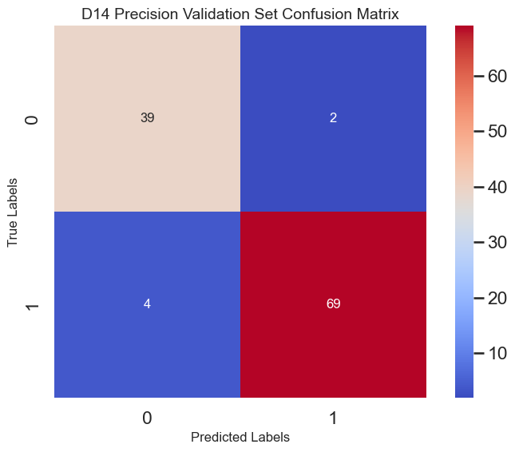

```python
# Create a figure and axis object
fig, ax = plt.subplots(1, 1, figsize=(8, 6))

# Plot the heatmap for the precision confusion matrix
plot_heatmap(precision_confusion_matrix, ax, 'D14 Precision Validation Set Confusion Matrix')

# Adjust layout to fit properly
plt.tight_layout()

# Display the plot
plt.show()
```

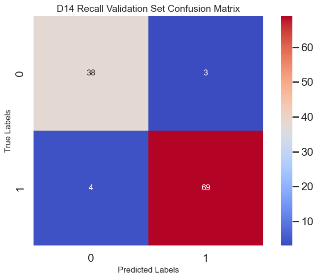

```python
# Create a figure and axis object
fig, ax = plt.subplots(1, 1, figsize=(8, 6))

# Plot the heatmap for the recall confusion matrix
plot_heatmap(recall_confusion_matrix, ax, 'D14 Recall Validation Set Confusion Matrix')

# Adjust layout to fit properly
plt.tight_layout()

# Display the plot
plt.show()
```

#### D14 Answer:

Given that the problem in this assignment is classification of breast cancer, the importance to capture as many positive instances as possible would be the focus and thus optimizing for recall would be preferable.

### Fitting a Decision Tree with optimal hyperparameters and a reduced feature set

#### D15 [1 mark]:

Using the model with fine-tuned hyperparameters based on accuracy (the one you obtained in D12), display the feature importance for each feature obtained from the training process. You should sort the feature importances in descending order.

```python
# Compute feature importances from the trained model
feature_importances = best_clf.feature_importances_

# Get the names of the features
features = X_train.columns

# Create a DataFrame to store feature names and their importances
importances_df = pd.DataFrame({
    'Feature': features,
    'Importance': feature_importances
})

# Round each importance score to 2 decimal places
importances_df['Importance'] = importances_df['Importance'].round(2)

# Sort the DataFrame by importance in descending order
importances_df = importances_df.sort_values(by='Importance', ascending=False)

# Reset the index of the DataFrame
importances_df = importances_df.reset_index(drop=True)

# Display the DataFrame containing feature importances
display(importances_df)
```

|  | Feature | Importance |
| --- | --- | --- |
| 0 | worst area | 0.80 |
| 1 | worst concave points | 0.15 |
| 2 | mean smoothness | 0.02 |
| 3 | mean texture | 0.01 |
| 4 | worst texture | 0.01 |
| 5 | mean area | 0.00 |
| 6 | mean compactness | 0.00 |
| 7 | worst symmetry | 0.00 |
| 8 | worst smoothness | 0.00 |
| 9 | worst fractal dimension | 0.00 |
| 10 | worst concavity | 0.00 |
| 11 | concave points error | 0.00 |
| 12 | worst compactness | 0.00 |
| 13 | concavity error | 0.00 |
| 14 | texture error | 0.00 |
| 15 | symmetry error | 0.00 |
| 16 | smoothness error | 0.00 |
| 17 | perimeter error | 0.00 |
| 18 | compactness error | 0.00 |
| 19 | mean symmetry | 0.00 |
| 20 | fractal dimension error | 0.00 |
| 21 | mean fractal dimension | 0.00 |
| 22 | mean concavity | 0.00 |
| 23 | mean concave points | 0.00 |
| 24 | area error | 0.00 |

#### D16 [3 marks]:

Using the feature importance you calculated in the previous task, trim the feature dimension of the data. That is, you should retain only those features whose importance values are above 1% (i.e., 0.01). You can either write your own Python code or use the function SelectFromModel from the sklearn.feature selection package to work out which feature(s) can be removed. Report what features were retained and removed in the above process. Also report the total feature importance value that is retained after your dimension reduction step.

```python
# Fit the model and select features with importance greater than 0.01
selector = SelectFromModel(estimator=best_clf, threshold=0.01).fit(X_train, y_train)

# Get the boolean mask indicating which features are retained
features_support = selector.get_support()

# List of all features
all_features = X_train.columns

# List of features to be retained
retained_features = all_features[features_support]

# List features that are removed
removed_features = all_features[~features_support]

# Total feature importance value retained
total_importance_retained = sum(selector.estimator_.feature_importances_[features_support])
```

```python
# Reporting
print("Features retained:", retained_features.tolist())
print("Features removed:", removed_features.tolist())
print("Total feature importance retained:", round(total_importance_retained,2))
```

[output not shown]

#### D17 [3 marks]:

Compare the model’s performance (accuracy, precision, recall) on training and test sets when using the reduced set of features and the model trained on the complete set of features. Also, report the corresponding confusion matrices on the test sets. (You will need to consider whether you should repeat the cross-validation process to find the optimal hyperparameters).

```python
# Remove features from the training and validation sets based on the list of removed features
X_train_D17 = X_train_D12.drop(labels=removed_features.tolist(), axis=1)
X_val_D17 = X_val_D12.drop(labels=removed_features.tolist(), axis=1)

# Make copies of the target variables
y_train_D17 = y_train_D12.copy()
y_val_D17 = y_val_D12.copy()

# Print the shapes of the updated training and validation sets
print(X_train_D17.shape, '\n', X_val_D17.shape)
```

```
(455, 5)
 (114, 5)
```

```python
# Fit the best classifier to the updated training set
best_clf.fit(X_train_D17, y_train_D17)
```

```
DecisionTreeClassifier(max_depth=3, min_samples_leaf=2, random_state=5508)
```

```python
# Define the parameter grid for the decision tree classifier
param_grid = {
    'max_depth': [2, 3, 4, 5],
    'min_samples_split': [2, 4, 5, 10],
    'min_samples_leaf': [2, 5]
}

# Create a decision tree classifier
clf_D17 = DecisionTreeClassifier(random_state=5508)

# Perform grid search with 10-fold cross-validation
grid_search_D17 = GridSearchCV(clf_D17, param_grid, cv=skf, scoring='accuracy', n_jobs=-1, verbose=1)

# Fit the grid search to the data
grid_search_D17.fit(X_train_D17, y_train_D17)

# Get the best parameters and the best score found during the grid search
best_params_D17 = grid_search_D17.best_params_
best_score_D17 = grid_search_D17.best_score_

# Print the best parameters and best accuracy score
print("Best Parameters:", best_params_D17)
print("Best Accuracy Score:", round(best_score_D17,2))
```

```
Fitting 10 folds for each of 32 candidates, totalling 320 fits
Best Parameters: {'max_depth': 4, 'min_samples_leaf': 2, 'min_samples_split': 5}
Best Accuracy Score: 0.95
```

Since the grid search has given us a different best parameter fields and values, we will stick to the model created in D12 as our task is to Compare the model’s performance (accuracy, precision, recall) on training and test sets when using the reduced set of features and the model trained on the complete set of features. Hence the model should remain the same and the features will be the difference to compare. Should the need to use a different set of parameters is required, the above model can then be used.

```python
# Initialize a decision tree classifier with the best parameters found during the grid search
clf_D17 = clone(best_clf)
# Fit the classifier to the updated training set
clf_D17.fit(X_train_D17, y_train_D17)
```

```
DecisionTreeClassifier(max_depth=3, min_samples_leaf=2, random_state=5508)
```

```python
# Predictions on the training set using the model with reduced parameters
y_train_pred_reduced_parameter = clf_D17.predict(X_train_D17)

# Predictions on the validation set using the model with reduced parameters
y_val_pred_reduced_parameter = clf_D17.predict(X_val_D17)

# Compute the training and validation results
D17_train_val_results = {
    'train_results_D17': {
        'Accuracy': round(accuracy_score(y_train_D17, y_train_pred_reduced_parameter),2),
        'Precision': round(precision_score(y_train_D17, y_train_pred_reduced_parameter, average='macro'),2),
        'Recall': round(recall_score(y_train_D17, y_train_pred_reduced_parameter, average='macro'),2),
    },
    'val_results_D17': {
        'Accuracy': round(accuracy_score(y_val_D17, y_val_pred_reduced_parameter),2),
        'Precision': round(precision_score(y_val_D17, y_val_pred_reduced_parameter, average='macro'),2),
        'Recall': round(recall_score(y_val_D17, y_val_pred_reduced_parameter, average='macro'),2),
    }
}

# Create a DataFrame from the results dictionary
D17_train_val_results = pd.DataFrame.from_dict(D17_train_val_results, orient='index')
```

```python
print("D17 Results: ")

# Display the training and validation results for the model trained with the reduced feature set
display(D17_train_val_results)
```

```
D17 Results:
```

|  | Accuracy | Precision | Recall |
| --- | --- | --- | --- |
| train_results_D17 | 0.96 | 0.97 | 0.96 |
| val_results_D17 | 0.94 | 0.93 | 0.94 |

```python
print("D12 Results: ")

# Display the training and validation results for the model trained with the best parameters found during grid search on the full feature set
display(D12_train_val_results_df)
```

```
D12 Results:
```

|  | Accuracy | Precision | Recall |
| --- | --- | --- | --- |
| train_results_D12 | 0.96 | 0.97 | 0.96 |
| val_results_D12 | 0.94 | 0.93 | 0.94 |

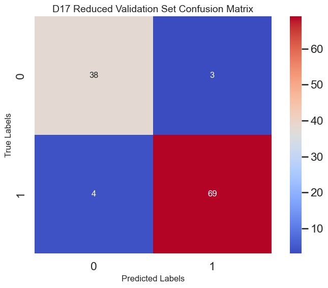

```python
# Compute the confusion matrix for the model trained with reduced parameters
reduced_confusion_matrix = confusion_matrix(y_val_D17, y_val_pred_reduced_parameter)

# Create a figure and axis object for the heatmap
fig, ax = plt.subplots(1, 1, figsize=(8, 6))

# Plot the heatmap of the confusion matrix
plot_heatmap(reduced_confusion_matrix, ax, 'D17 Reduced Validation Set Confusion Matrix')

# Adjust layout to fit properly
plt.tight_layout()

# Display the plot
plt.show()
```

#### D17 Answer:

Based on initial comparisons of the results, we can see that both D17 and D12 results are identical.

#### D18 [1 mark]:

Comment on your results. What was the impact (if any) of reducing the number of features?

#### D18 Answer:

The D17 and D12 results, trained on the same model with reduced and complete set of features respectively, display equivalent performance across most metrics on both training and validation datasets, contradicting initial expectations that reducing the feature set might lead to a discernible difference in model efficacy.

Accuracy, Precision, Recall (Training and Validation): Both models achieved identical scores on training results with an accuracy of 0.96, precision of 0.97, and recall of 0.96. The validation results for both models also matched perfectly with an accuracy of 0.94, precision of 0.93, and recall of 0.94.

This uniformity suggests that the removal of features in the D17 model did not significantly impact its ability to generalize compared to the D12 model, which utilized the complete set of features. The confusion matrices as well are identical, indicating no difference in the classification errors made by both models. Both models have effectively the same true and false positives/negatives, highlighting their similar predictive abilities on the validation set.

Given these results, it may not be necessary to repeat the cross-validation process to find optimal hyperparameters specifically for the reduced feature set, as the existing model configuration seems to maintain performance effectively. This equivalence also implies that the complexity reduction in the D17 model (through feature reduction) does not compromise the model's ability to generalize, making it a potentially more efficient choice without sacrificing accuracy.

### Fitting a Random Forest

#### D19 [3 marks]:

Considering all features and the 80%-20% data split you did before, use 10-fold cross-validation and grid-search to find a Random Forest classifier’s optimal hyperparameters n estimators (number of estimators) and max depth. Remember to set the seed of the random state of the data split function and model class to the value “5508”. Use n estimators:[10, 20, 50, 100, 1000], and max depth:[2, 3, 4, 5]. For the cross-validation, set the value of the random state to “42”. Use accuracy for the scoring argument of the grid-search function.

Keep the other hyperparameter values to their default values. Use the optimal values for the n estimators and max depth hyperparameters to retrain the model and report:

- The obtained optimal number of estimators and max depth;
- The obtained accuracy, precision and recall on the training set;
- The obtained accuracy, precision and recall on the test set;
- The confusion matrix on the test set.

```python
# Define the parameter grid for Random Forest
param_grid = {
    'n_estimators' : [10, 20, 50, 100, 1000],
    'max_depth' : [2, 3, 4, 5]
}

# Instantiate a Random Forest classifier
rf = RandomForestClassifier(random_state=5508)

# Perform grid search with 10-fold cross-validation
grid_search_rf = GridSearchCV(rf, param_grid, cv=skf, scoring='accuracy', n_jobs=-1, verbose=1)

# Fit the grid search to the data
grid_search_rf.fit(X_train, y_train)

# Get the best parameters and the best score
best_params_rf = grid_search_rf.best_params_
best_score_rf = grid_search_rf.best_score_

# Print the best parameters and best accuracy score
print("Best Parameters:", best_params_rf)
print("Best Accuracy Score:", round(best_score_rf,2))
```

```
Fitting 10 folds for each of 20 candidates, totalling 200 fits
Best Parameters: {'max_depth': 4, 'n_estimators': 100}
Best Accuracy Score: 0.96
```

```python
# Train a new Random Forest model with the best parameters on the full training set

# Instantiate a Random Forest classifier with the best parameters
best_rf = RandomForestClassifier(random_state=5508, **best_params_rf)

# Train the Random Forest classifier on the full training set
best_rf.fit(X_train, y_train)
```

```
RandomForestClassifier(max_depth=4, random_state=5508)
```

```python
# Calculate predictions and evaluation metrics for the Random Forest model
y_train_pred_rf = best_rf.predict(X_train)
y_val_pred_rf = best_rf.predict(X_val)

# Define a dictionary to store hyperparameters, training results, and validation results
rf_train_val_results = {
    'hyper_parameters': {
        'Best_Parameters' : best_params_rf  # Store the best parameters found during grid search
    },
    'train_results': {
        'Accuracy': round(accuracy_score(y_train, y_train_pred_rf),2),  # Calculate accuracy on the training set
        'Precision': round(precision_score(y_train, y_train_pred_rf, average='macro'),2),  # Calculate precision on the training set
        'Recall': round(recall_score(y_train, y_train_pred_rf, average='macro'),2),  # Calculate recall on the training set
    },
    'val_results': {
        'Accuracy': round(accuracy_score(y_val, y_val_pred_rf),2),  # Calculate accuracy on the validation set
        'Precision': round(precision_score(y_val, y_val_pred_rf, average='macro'),2),  # Calculate precision on the validation set
        'Recall': round(recall_score(y_val, y_val_pred_rf, average='macro'),2),  # Calculate recall on the validation set
    }
}
```

```python
# Convert the dictionary containing results to a DataFrame for better display
rf_train_val_results_df = pd.DataFrame.from_dict(rf_train_val_results, orient='index')

# Display the DataFrame
display(rf_train_val_results_df)
```

|  | Best_Parameters | Accuracy | Precision | Recall |
| --- | --- | --- | --- | --- |
| hyper_parameters | {'max_depth': 4, 'n_estimators': 100} | NaN | NaN | NaN |
| train_results | NaN | 0.99 | 0.99 | 0.99 |
| val_results | NaN | 0.98 | 0.98 | 0.98 |

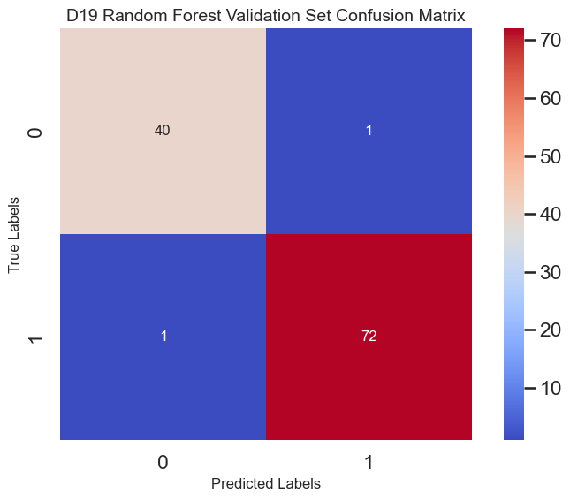

```python
# Calculate the confusion matrix for the Random Forest model on the validation set
rf_confusion_matrix = confusion_matrix(y_val, y_val_pred_rf)

# Create a figure and axis object
fig, ax = plt.subplots(1, 1, figsize=(8, 6))

# Plot the heatmap of the confusion matrix
plot_heatmap(rf_confusion_matrix, ax, 'D19 Random Forest Validation Set Confusion Matrix')

# Adjust layout to fit properly
plt.tight_layout()

# Display the plot
plt.show()
```

#### D20 [2 marks]:

How do these performances compare with the ones you obtained in D12? What changed with the use of a Random Forest model? Is this result what you would expect?

#### D20 Answer:

The use of the Random Forest model, with its ensemble learning approach, appears to have led to a more robust and accurate model than the single Decision Tree. This is evident in both the improved accuracy score and the confusion matrix. The Random Forest model's ability to reduce both type I and type II errors suggests a model that is more reliable for making predictions on this dataset. The results align with common expectations where ensemble methods outperform single estimators.

#### D21 [2 marks]:

Thinking about the application and the different models you created, discuss:

- Do you think these models are good enough and can be trusted to be used for real?
- Do you think a more complex model is necessary?
- Do you think using a machine learning algorithm for this task is a good idea? That is, should this decision process be automated? Justify.
- Are there considerations with the used dataset?

#### D21 Answer:

1. Model Trustworthiness and Suitability for Real-World Use: - The severity and implications of potential misdiagnoses (false positives and false negatives) must be considered. In medical applications like breast cancer diagnosis, high recall (sensitivity) might be prioritized to ensure that as few cases of cancer as possible are missed. If the models demonstrate sufficiently high and consistent recall across various configurations, they could be considered reliable enough for practical use, possibly as a preliminary screening tool rather than a definitive diagnostic method.
2. Necessity of More Complex Models: - The decision to employ more complex models should be based on the specific requirements of accuracy and the nature of the dataset. Complex models, such as deep learning models, may capture intricate patterns in the data that simpler models might miss. However, they also require more data to train effectively and can be prone to overfitting. Given the current performance of the existing models (if they are already high), adding complexity might not yield significant improvements and could complicate interpretation and maintenance.
3. Appropriateness of Automating the Decision Process: - Automating breast cancer diagnosis through machine learning can increase the efficiency and accessibility of screening and preliminary assessments. It can help in handling large volumes of data and assist in early detection where radiologist availability is limited.

```
- However, the decision to fully automate should be approached with caution. The machine learning model should ideally operate in conjunction with human experts, serving as a support tool to augment the diagnostic process rather than replacing human judgment. This dual approach helps mitigate the risks associated with potential errors in the model's predictions.
```

4. Considerations with the Used Dataset: - The quality and diversity of the dataset are crucial. The scikit-learn breast cancer dataset is relatively clean and well-prepared, but it may not represent the broader population diversity seen in real-world settings. Factors such as age, race, and other health conditions might influence the model's performance and generalizability.

```
- The dataset's size and the balance between classes (benign vs. malignant) are also important. If the dataset is imbalanced, it could bias the model, resulting in poorer performance on the minority class.
```